# RNA-Seq Differential Expression

Jessica Murphy

April 2, 2019

### Overview

The following data was obtained from a 2x2 factorial design using fly models. The two variables of interest are strain and tissue. The strains are white eyed (W) and sevenless (S) and the tissues are optic lope (O) and retina (R). There are four samples in each tissue/strain combination.

The dataset contains a matrix of RSEM expected counts for 17,453 genes and a matrix of phenotypes to accompany the counts.

### Visualize Data

The dendrogram below was initially constructed to look at the data. Note: The y-axis represents distance, or dissimilarity.

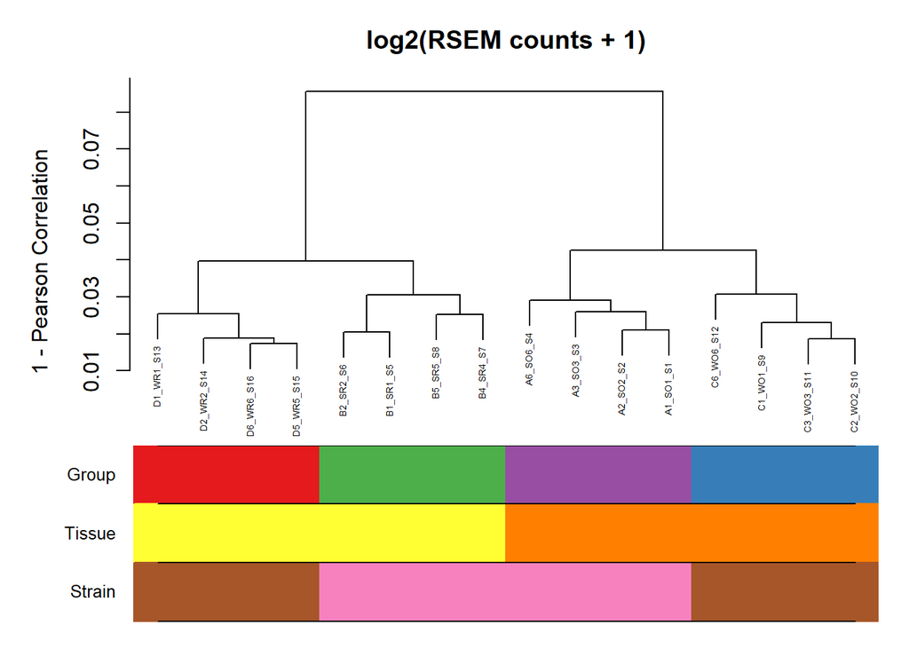

The diagram shows clustering by groups really well. Tissue explains the main distance (first break at 0.1) and strain explains the second most distance (second break around 0.05).

Principal component analysis (PCA) was also performed on the data and the PC plots of the 16 samples are shown below.

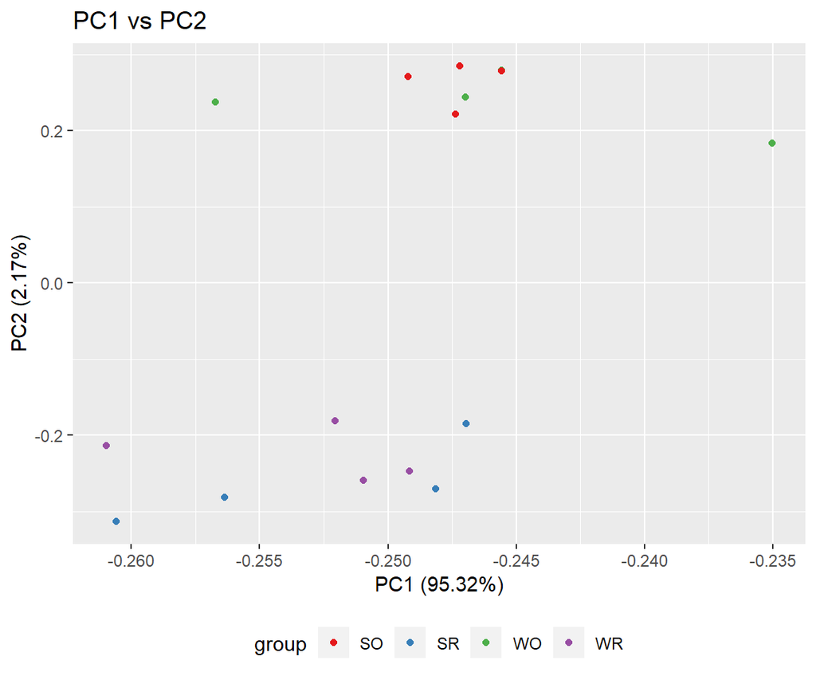

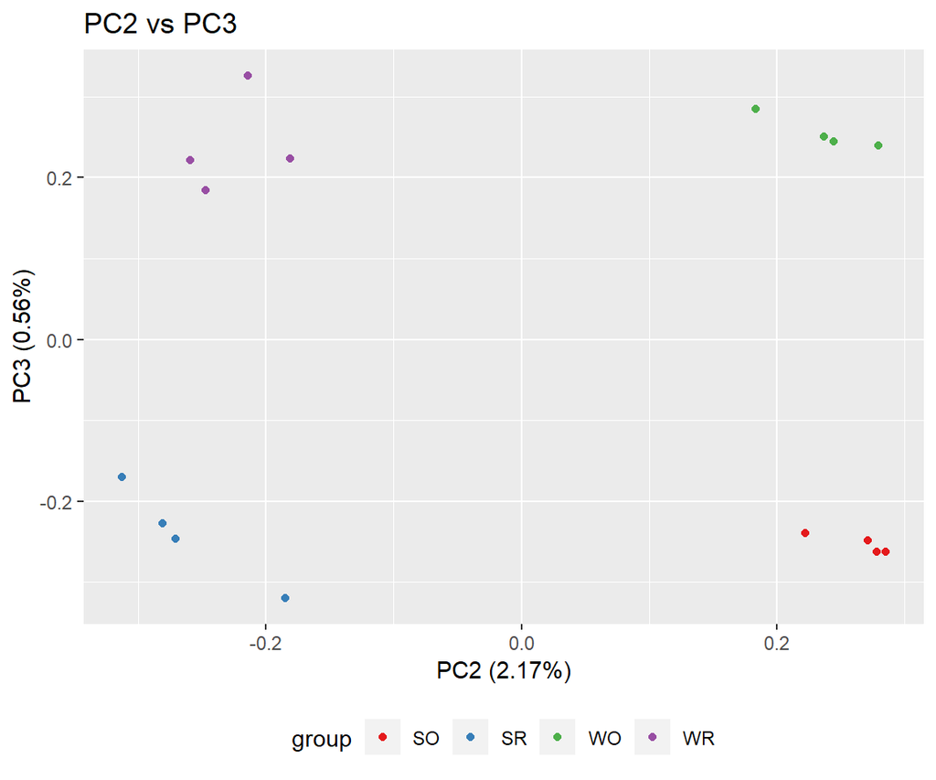

The PC1 vs PC2 plot shows a large separation in tissue type on PC2. Also, a very large percent of the variance is explained by PC1. The PC2 vs PC3 plot shows a great separation in groups. PC2 describes tissue differences (2nd letter in group) and PC3 describes strain differences (1st letter in group).

### Perform Statistical Test

A liklihood ratio test (LRT) was then performed using DESeq2 to determine which genes have a significant strain effect regardless of dependence/independence on tissue.

Based on an adjusted p-value < 0.05, there were 2,098 gene candidates. Since this is such a large amount, a stricter criteria was applied. Based on an adjusted p-value < 0.001, there are now 878 gene candidates. The top 10 candidates are listed below.

|  | Base Mean | log2 Fold Change | Adjusted p-value |
| --- | --- | --- | --- |
| FBgn0052475 | 846.31527 | 2.0922266 | 0.000000e+00 |
| FBgn0267160 | 770.14610 | 1.4761384 | 4.408069e-289 |
| FBgn0050428 | 177.59063 | -3.6259762 | 8.239672e-174 |
| FBgn0051865 | 86.33801 | 0.5608518 | 9.706659e-145 |
| FBgn0052011 | 159.10743 | 1.4197483 | 1.499746e-132 |
| FBgn0051676 | 2087.10410 | 0.4941369 | 6.383283e-109 |
| FBgn0037228 | 1543.28030 | -0.0275406 | 2.984941e-99 |
| FBgn0040524 | 85.36571 | 3.3180130 | 4.973883e-91 |
| FBgn0015714 | 66.40389 | 2.3278783 | 3.621200e-88 |
| FBgn0058469 | 4589.87052 | 0.4486818 | 1.558954e-83 |

### Visualize Candidates

The following heatmap shows the top 100 candidates with the smallest adjusted p-values. This is good to see large trends, but difficult to see individual genes.

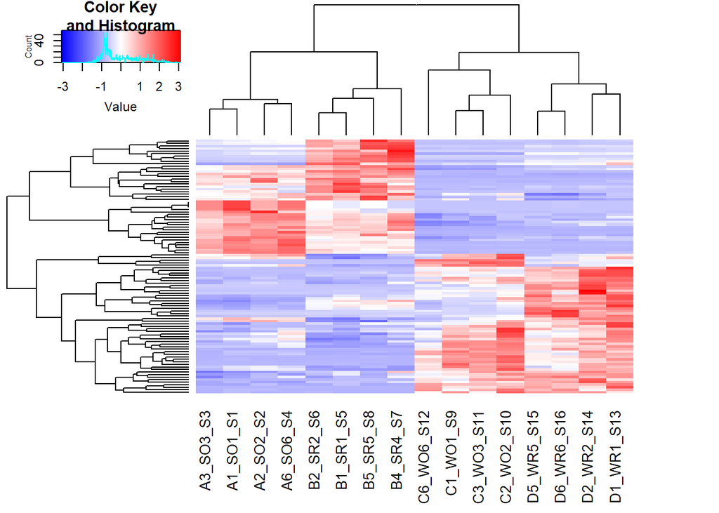

### Perform Enrichment Analysis

Finally, enrichment analysis was performed using enrichR to determine if the previous 100 candidates are part of any known biological pathway or system.

The flybase gene IDs were first converted to 110 human associated genes. Using the GO Biological Process 2018 database, the top 10 processes with the smallest adjusted p-values are listed below.

| Process | Overlap | Adjusted p-value |
| --- | --- | --- |
| regulation of ARF protein signal transduction (GO:0032012) | 20/31 | 5.232546e-36 |
| regulation of Ras protein signal transduction (GO:0046578) | 20/91 | 1.563793e-24 |
| extracellular matrix organization (GO:0030198) | 18/230 | 1.073507e-13 |
| vesicle-mediated transport (GO:0016192) | 21/411 | 1.246295e-12 |
| transmembrane transport (GO:0055085) | 19/379 | 3.116485e-11 |
| cell-matrix adhesion (GO:0007160) | 10/91 | 8.653487e-09 |
| heterotypic cell-cell adhesion (GO:0034113) | 6/26 | 5.278106e-07 |
| endodermal cell differentiation (GO:0035987) | 5/33 | 8.855913e-05 |
| mesodermal cell differentiation (GO:0048333) | 3/10 | 1.413237e-03 |
| short-chain fatty acid catabolic process (GO:0019626) | 2/9 | 4.182513e-02 |